# STOR 455 Class 35 R Notebook

Homework 8 comments - you have to pick 6 dif models of car and use a random sample selection of 50 cars - choose these cars that are from jap or us companies; they are not part of the sample, but you have the car names - you’ll have to deduce which are jap vs us cars; do based on what they car type name is; think about the company - choose 3 jap cars that are a compact, midsize and suv - you have to find this yourself - Goal: take samples of 50 and find the compact, midsize, and suv for - use rbind like HW 4 to put all in the same dataframe (left join) - make a new variable - a bit of a setup - reference hw 2 and 4

```r
library(readr)

Exams4 <- read_csv("https://raw.githubusercontent.com/JA-McLean/STOR455/master/data/Exams4.csv")
Diet <- read_csv("https://raw.githubusercontent.com/JA-McLean/STOR455/master/data/Diet.csv")
```

Last time talked about anova for a difference in k mean - if we split it up into groups and classify the mean for the group that it is in, does that explain a significant amount more of the variability? Aka: Should we classify things by their group mean or the overall mean?

*Hypo test* Ho: mu1 = mu2=…muk Ha: some mui != muj

We looked to see if there is sig dif in the average grade among the four exams? Or are teh results by chance?

*Partiioning Variability* Data = Model + Error Y = mui + E total varaition in the response, Y = variation explained by MODEL + Unexplained variation in Residuals

Question: Does the model explain a sig amount of the total variability?

the error term is what variabiltiy there is grom each group mean

*Partitioning Variability ANOVA for Group Means* Y = muk + E SSTotal = SSGroups + SSE

The SSTotal = the SSdifferences from the overal gran mean SSE = sum of the difference from each indiivdual group mean SSGroup = the variation explained by the groups that we have imposed on this model

If we have sig evi of the diff bt the means, then the model will have SSE = small compared to the SSGroup; b/c the SSGroup tells us if a lot of the variability has been explained by using the group means

*Below is the model we made last class*

Ho: all exam means are equal in population Ha: at least one exam mean is different

The pvalue is big, so there is no evidece for sig dif

**Below:** IF we sum these, then we get the total SS; SSTotal; if we have a good model, then we would want a lot of variability explained by our groups factor(Exam) and we see there is a lot in the residuals, which is below factor(Exam) - this is why we have a large p value

```r
amodG=aov(Grade~factor(Exam),data=Exams4)
summary(amodG)
```

```
             Df Sum Sq Mean Sq F value Pr(>F)
factor(Exam)  3   1030   343.3   1.056  0.395
Residuals    16   5200   325.0
```

*Checking conditions for ANOVA* *Mostly have to focus on constant variance and normality* -Zero mean: Always holds for sample residuals - Constant Variance = plot residuals vs fits and/or compare std dev.’s of group (check if some groups is is more than twice another) *can be hard to check since we ar looking at groups; and sometimes its just teh mean values; we want to see a similar spread between the groups; can also think that as long as the largest standard deviation is not double the smallest standard deviation, then we ar egood enough for constant variance.* (Think more about the data, because if you have a really small dataset, you might have to throw that idea out the window) - normality: histogram/normal QQplot of residuals - Independence: Pay attention to how the data was collected

**Below: Checking Residuals** This amount of devation is not a problem

**Below: We check to see wht the std are of the functions**

This will split it by categories.

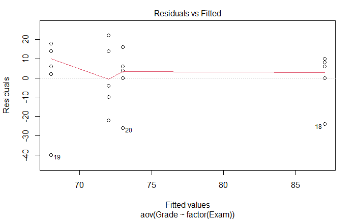

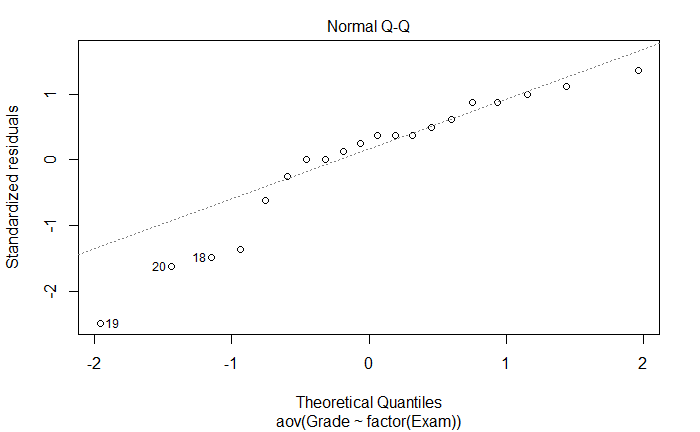

```r
plot(amodG, 1:2)
```

```r
round(tapply(Exams4$Grade,Exams4$Exam,sd),2)
```

```
    1     2     3     4
17.89 13.93 23.24 15.68
```

*Question* Is there sig dif in the average grade among the five students? Is it a sig dif?

```r
round(tapply(Exams4$Grade,Exams4$Student,sd),2)
```

```
 Barb Betsy  Bill   Bob   Bud
10.30  4.24 10.98 11.40 14.45
```

*How many comparisions?* Which one of the indivates caused the sig difference?

There could be a lot of comparisions to do.

*Problem of Multiplicity* When we are doing many pairwaise comparisions we are more likely to make a Tpye I Effor (finding a false difference)

**Possible fixes:** - Do only a few pre planned comparisons – If we know what we want to focus on, then we can do that - Adjust the sig level used for each test

- THe more testes we do, the more like we are th make a type 1 error = null is true, but we find evidence to reject it

*Example:* If we did tests at a .05 sig level, then there is a 5% chance that we will make a type 1 error; so there is a 95% chance that we won’t make a type 1 error.

We have to find out how we can minimize the chance of making a tpye 1 error.

```r
# The probability of not making a type 1 error if you run 10 tests
(1 - 0.05)^10
```

```
[1] 0.5987369
```

```r
# Chance that we make at least 1 type 1 error when we do 10 tests
1 - (1 - 0.05)^10
```

```
[1] 0.4012631
```

```r
# The probability of not making a type 1 error if you run 100 tests
(1 - 0.05)^100
```

```
[1] 0.005920529
```

```r
# Chance that we make at least 1 type 1 error when we do 100 tests
1 - (1 - 0.05)^100
```

```
[1] 0.9940795
```

*Pairwise comparision AFTER ANOVA* This is where you do every single test on the data

Compute a C.I for mui - muj

Pairwaise t-test for difference in means Ho: mui = muj Ha: mui != muj

*Modifications* - estimate any std with sqrt(MSE) = Se - Use teh error d.f for any t-values